# Berry project

Lin Zhou

2020/10/17

## Berries EDA report

In this report, I am going to do the exploratoary data analysis about “berries” dataset. These data were collected from the USDA database selector which can be found on https://quickstats.nass.usda.gov The data were stored online and then downloaded as a CSV file.Data selected from the NASS database often has columns without any data or with a single repeated Values. I am going to clean the data and show the meaningful values of variables under each columns.

## Data cleaning

First, let’s start with a few packages which would be used in the following data cleaning and visualization process.

```r
library(dplyr)
library(tidyr)
library(tidyverse)
library(magrittr)
library(stringr)
library(funModeling)
library(Hmisc)
```

After importing the “berries” dataset, I would like to check the distinction of the values under each column. Since many of the columns have only NA and single repeated value which can not make any sense when doing the data analysis, I would like to remove them from the dataset.

```r
berries <- read.csv("berries.csv")
num_value <- berries%>%summarize_all(n_distinct)
select_col <- num_value[which(num_value[1,]==1)]
index_col <- which(num_value[1,] == 1)
berries[,c(1,4,5,8,9,10,11,12,13,14,15,21)]
```

[output not shown]

[output cut: 16654 more lines]

```r
berries$Data.Item <- gsub("[()]", "", berries$Data.Item)
new <- separate(berries, col = Data.Item, into = c("berry","type", "data_type", "unit"), sep = ",")
new$Domain <- gsub("[()]", "", new$Domain)
new1 <- separate(new, col = Domain, into = c("component","agent type"), sep = ",")
head(berries)
```

```
##   Program Year         Period Week.Ending Geo.Level      State State.ANSI
## 1  SURVEY 2019 MARKETING YEAR          NA     STATE CALIFORNIA          6
## 2  SURVEY 2019 MARKETING YEAR          NA     STATE CALIFORNIA          6
## 3  SURVEY 2019 MARKETING YEAR          NA     STATE CALIFORNIA          6
## 4  SURVEY 2019 MARKETING YEAR          NA     STATE CALIFORNIA          6
## 5  SURVEY 2019 MARKETING YEAR          NA     STATE CALIFORNIA          6
## 6  SURVEY 2019 MARKETING YEAR          NA     STATE CALIFORNIA          6
##   Ag.District Ag.District.Code County County.ANSI Zip.Code Region
## 1          NA               NA     NA          NA       NA     NA
## 2          NA               NA     NA          NA       NA     NA
## 3          NA               NA     NA          NA       NA     NA
## 4          NA               NA     NA          NA       NA     NA
## 5          NA               NA     NA          NA       NA     NA
## 6          NA               NA     NA          NA       NA     NA
##   watershed_code Watershed   Commodity
```

[output cut: 20 more lines]

```r
new1$Domain.Category <- gsub("[()]", "", new1$Domain.Category)
new2 <- separate(new1, col = Domain.Category, into = c("agentia","compound"), sep = ",")
head(new2)
```

```
##   Program Year         Period Week.Ending Geo.Level      State State.ANSI
## 1  SURVEY 2019 MARKETING YEAR          NA     STATE CALIFORNIA          6
## 2  SURVEY 2019 MARKETING YEAR          NA     STATE CALIFORNIA          6
## 3  SURVEY 2019 MARKETING YEAR          NA     STATE CALIFORNIA          6
## 4  SURVEY 2019 MARKETING YEAR          NA     STATE CALIFORNIA          6
## 5  SURVEY 2019 MARKETING YEAR          NA     STATE CALIFORNIA          6
## 6  SURVEY 2019 MARKETING YEAR          NA     STATE CALIFORNIA          6
##   Ag.District Ag.District.Code County County.ANSI Zip.Code Region
## 1          NA               NA     NA          NA       NA     NA
## 2          NA               NA     NA          NA       NA     NA
## 3          NA               NA     NA          NA       NA     NA
## 4          NA               NA     NA          NA       NA     NA
## 5          NA               NA     NA          NA       NA     NA
## 6          NA               NA     NA          NA       NA     NA
##   watershed_code Watershed   Commodity                        berry
```

[output cut: 20 more lines]

Then I want to look into specific type of berry and acquire the information about it. Let blueberry dataset as an example. First and foremost, I extract blueberry dataset from the whole dataset and recheck every values are meaningful and in the right place. After checking the positions of values under each column, I found some of values under columns (type, data_type, unit) are not in the right place. As a result, I create two for loops to adjust them into right rail. Since if there is stirng “MEASURED” appearing under “type” column, the unit column would be “NA”, we need firstly adjust the values under “type” column, and then “unit” column. Also, if there is string “MEASURED” appearing under “unit” column, I need to not only tranfer the value from unit to data_type, but also combine former data_type value to type value. Thus, before I tranfer the value from unit column, I would like to set a temp column to store the value of data_type value.

```r
bberry_index <- which(new2[,16] == "BLUEBERRIES")
bberry <- new2[bberry_index,]
unique(bberry$data_type)
```

```
##  [1] " MEASURED IN $ / LB"
##  [2] " FRESH MARKET - PRICE RECEIVED"
##  [3] " PROCESSING - PRICE RECEIVED"
##  [4] NA
##  [5] " MEASURED IN LB"
##  [6] " MEASURED IN LB / ACRE"
##  [7] " FRESH MARKET - PRODUCTION"
##  [8] " NOT SOLD - PRODUCTION"
##  [9] " PROCESSING - PRODUCTION"
## [10] " UTILIZED - PRODUCTION"
## [11] " MEASURED IN LB / ACRE / APPLICATION"
## [12] " MEASURED IN LB / ACRE / YEAR"
## [13] " MEASURED IN NUMBER"
## [14] " MEASURED IN PCT OF AREA BEARING"
## [15] " UTILIZED - YIELD"
## [16] " NOT HARVESTED - PRODUCTION"
```

```r
unique(bberry$unit)
```

```
## [1] NA                       " MEASURED IN $ / LB"    " MEASURED IN $"
## [4] " MEASURED IN LB"        " AVG"                   " MEASURED IN LB / ACRE"
```

```r
bberry[is.na(bberry)]= "NA"
for (i in 1:length(bberry$type)){
  if(str_detect(bberry$type[i], "MEASURED")){
    bberry$data_type[i] = bberry$type[i]
    bberry$type[i] = "NA"
  }
}
bberry$btemp <- ""
for (i in 1:length(bberry$Year)){
  if(str_detect(bberry$unit[i], "MEASURED")){
    bberry$btemp[i] = bberry$data_type[i]
    bberry$data_type[i] = bberry$unit[i]
    bberry$unit[i] = "NA"
  }
}
bberry$type = cbind(bberry$type,bberry$btemp)
```

Then, I do the same thing on raspberry and strawberry dataset.

```r
sberry_index <- which(new2[,16] == "STRAWBERRIES")
sberry <- new2[sberry_index,]
unique(sberry$data_type)
```

```
##  [1] NA
##  [2] " MEASURED IN $ / CWT"
##  [3] " MEASURED IN LB"
##  [4] " MEASURED IN LB / ACRE / APPLICATION"
##  [5] " MEASURED IN LB / ACRE / YEAR"
##  [6] " MEASURED IN NUMBER"
##  [7] " MEASURED IN PCT OF AREA BEARING"
##  [8] " MEASURED IN $"
##  [9] " UTILIZED - PRODUCTION"
## [10] " MEASURED IN CWT"
## [11] " MEASURED IN $ / TON"
```

```r
unique(sberry$unit)
```

```
## [1] NA                  " AVG"              " MEASURED IN CWT"
## [4] " MEASURED IN TONS"
```

```r
sberry[is.na(sberry)]= "NA"
for (i in 1:length(sberry$type)){
  if(str_detect(sberry$type[i], "MEASURED")){
    sberry$data_type[i] = sberry$type[i]
    sberry$type[i] = "NA"
  }
}
sberry$stemp <- ""
for (i in 1:length(sberry$Year)){
  if(str_detect(sberry$unit[i], "MEASURED")){
    sberry$stemp[i] = sberry$data_type[i]
    sberry$data_type[i] = sberry$unit[i]
    sberry$unit[i] = "NA"
  }
}
sberry$type = cbind(sberry$type,sberry$stemp)


rberry_index <- which(new2[,16] == "RASPBERRIES")
rberry <- new2[rberry_index,]
unique(rberry$type)
```

```
##  [1] " MEASURED IN $ / LB"            " FRESH MARKET - PRICE RECEIVED"
##  [3] " PROCESSING - PRICE RECEIVED"   NA
##  [5] " MEASURED IN LB"                " MEASURED IN LB / ACRE"
##  [7] " BEARING - APPLICATIONS"        " BEARING - TREATED"
##  [9] " FRESH MARKET - PRODUCTION"     " NOT SOLD - PRODUCTION"
## [11] " PROCESSING - PRODUCTION"       " UTILIZED - PRODUCTION"
## [13] " BLACK - PRICE RECEIVED"        " BLACK"
## [15] " RED - PRICE RECEIVED"          " RED"
## [17] " BLACK - ACRES HARVESTED"       " BLACK - PRODUCTION"
## [19] " RED - ACRES HARVESTED"         " RED - PRODUCTION"
## [21] " UTILIZED - YIELD"              " NOT HARVESTED - PRODUCTION"
```

```r
unique(rberry$data_type)
```

```
##  [1] NA
##  [2] " MEASURED IN $ / LB"
##  [3] " MEASURED IN LB"
##  [4] " MEASURED IN LB / ACRE / APPLICATION"
##  [5] " MEASURED IN LB / ACRE / YEAR"
##  [6] " MEASURED IN NUMBER"
##  [7] " MEASURED IN PCT OF AREA BEARING"
##  [8] " MEASURED IN $"
##  [9] " FRESH MARKET - PRICE RECEIVED"
## [10] " PROCESSING - PRICE RECEIVED"
## [11] " FRESH MARKET - PRODUCTION"
## [12] " NOT SOLD - PRODUCTION"
## [13] " PROCESSING - PRODUCTION"
## [14] " UTILIZED - PRODUCTION"
## [15] " UTILIZED - YIELD"
## [16] " MEASURED IN LB / ACRE"
## [17] " NOT HARVESTED - PRODUCTION"
```

```r
unique(rberry$unit)
```

```
## [1] NA                       " AVG"                   " MEASURED IN $ / LB"
## [4] " MEASURED IN $"         " MEASURED IN LB"        " MEASURED IN LB / ACRE"
```

```r
rberry[is.na(rberry)]= "NA"
for (i in 1:length(rberry$type)){
  if(str_detect(rberry$type[i], "MEASURED")){
    rberry$data_type[i] = rberry$type[i]
    rberry$type[i] = "NA"
  }
}
rberry$rtemp <- ""
for (i in 1:length(rberry$Year)){
  if(str_detect(rberry$unit[i], "MEASURED")){
    rberry$rtemp[i] = rberry$data_type[i]
    rberry$data_type[i] = rberry$unit[i]
    rberry$unit[i] = "NA"
  }
}
rberry$type = cbind(rberry$type,rberry$rtemp)
```

## Data visualization

After I clean the data, I would like to choose specific dataset (strawberry dataset) to analyze. There are often 4 steps about EDA: 1.Acquire and understand the dataset. 2.Analyze the categorical variable. 3. Analyze the numeric variable. 4.Analyze these two types of variables at the same time. Keypoints needed to be paied attention to in EDA: data_type, outliers, NA, distributions. In the first step, I use the glimpse function to get to know the numbers of observations and first a few lines of the data. Then the df_status function would return a table contains information about the number of NA or unique value of each column. The fre function would return frequencies of all string and factor variables in the dataset and shows as histograms. And the plot_num function would deal with the numerical variables in the dataset which can show the distribution of values.

```
## Rows: 3,476
## Columns: 9
## $ Year      <int> 2019, 2019, 2019, 2019, 2019, 2019, 2019, 2019, 2019, 201...
## $ State     <chr> "CALIFORNIA", "CALIFORNIA", "CALIFORNIA", "FLORIDA", "FLO...
## $ berry     <chr> "STRAWBERRIES - PRICE RECEIVED", "STRAWBERRIES", "STRAWBE...
## $ type      <chr[,2]> "NA", " FRESH MARKET - PRICE RECEIVED", " PROCESSING ...
## $ data_type <chr> " MEASURED IN $ / CWT", " MEASURED IN $ / CWT", " MEASURE...
## $ unit      <chr> "NA", "NA", "NA", "NA", "NA", "NA", "NA", "NA", "NA", "NA...
## $ agentia   <chr> "NOT SPECIFIED", "NOT SPECIFIED", "NOT SPECIFIED", "NOT S...
## $ compound  <chr> "NA", "NA", "NA", "NA", "NA", "NA", "NA", "NA", "NA", "NA...
## $ Value     <chr> "108", " (D)", " (D)", "152", " (D)", " (D)", "129", "52....
##    variable q_zeros p_zeros q_na p_na q_inf p_inf         type unique
## 1      Year       0    0.00    0    0     0     0      integer      5
## 2     State       0    0.00    0    0     0     0    character     11
## 3     berry       0    0.00    0    0     0     0    character      6
## 4      type       0    0.00    0    0     0     0 matrix-array     22
## 5 data_type       0    0.00    0    0     0     0    character     12
## 6      unit       0    0.00    0    0     0     0    character      2
## 7   agentia       0    0.00    0    0     0     0    character      6
## 8  compound       0    0.00    0    0     0     0    character    157
## 9     Value      68    1.96    0    0     0     0    character    859
```

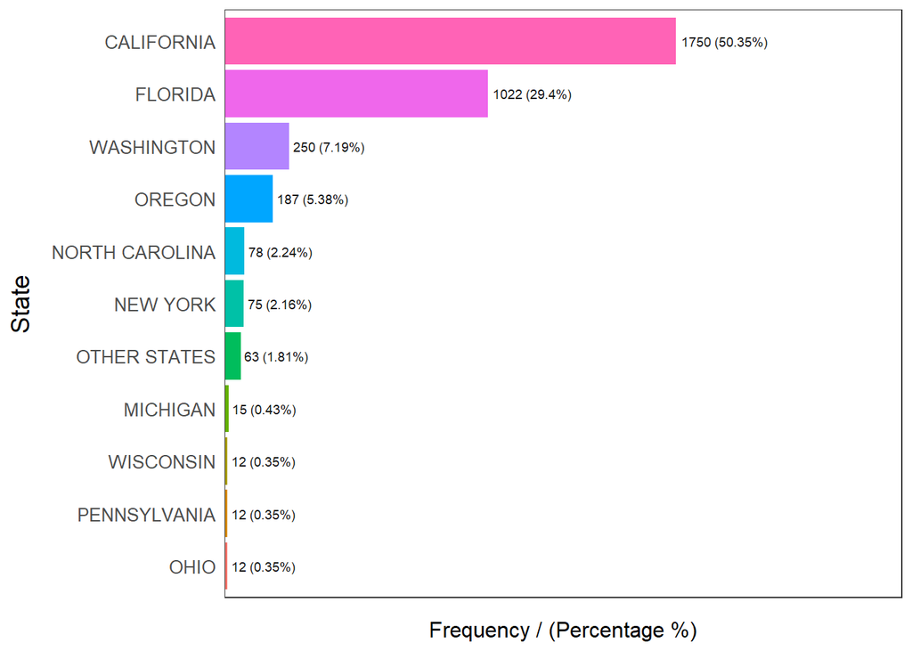

```
##             State frequency percentage cumulative_perc
## 1      CALIFORNIA      1750      50.35           50.35
## 2         FLORIDA      1022      29.40           79.75
## 3      WASHINGTON       250       7.19           86.94
## 4          OREGON       187       5.38           92.32
## 5  NORTH CAROLINA        78       2.24           94.56
## 6        NEW YORK        75       2.16           96.72
## 7    OTHER STATES        63       1.81           98.53
## 8        MICHIGAN        15       0.43           98.96
## 9            OHIO        12       0.35           99.31
## 10   PENNSYLVANIA        12       0.35           99.66
## 11      WISCONSIN        12       0.35          100.00
```

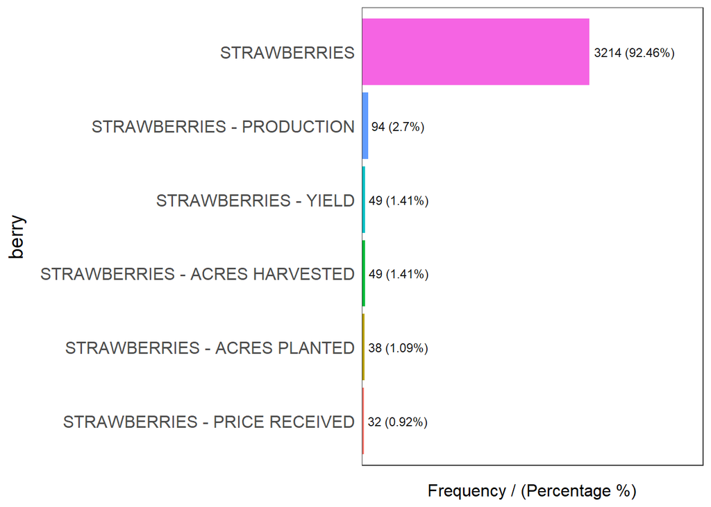

```
##                            berry frequency percentage cumulative_perc
## 1                   STRAWBERRIES      3214      92.46           92.46
## 2      STRAWBERRIES - PRODUCTION        94       2.70           95.16
## 3 STRAWBERRIES - ACRES HARVESTED        49       1.41           96.57
## 4           STRAWBERRIES - YIELD        49       1.41           97.98
## 5   STRAWBERRIES - ACRES PLANTED        38       1.09           99.07
## 6  STRAWBERRIES - PRICE RECEIVED        32       0.92          100.00
```

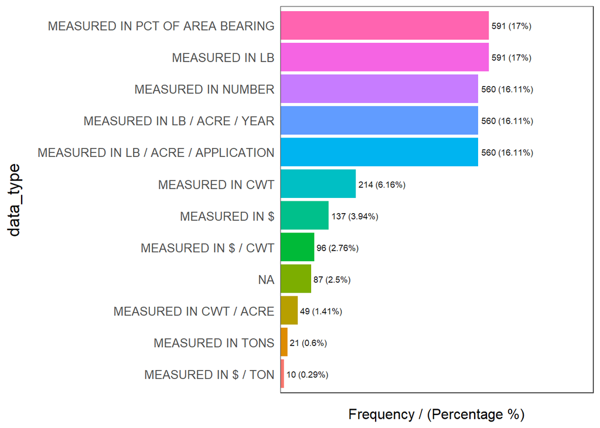

```
##                               data_type frequency percentage cumulative_perc
## 1                        MEASURED IN LB       591      17.00           17.00
## 2       MEASURED IN PCT OF AREA BEARING       591      17.00           34.00
## 3   MEASURED IN LB / ACRE / APPLICATION       560      16.11           50.11
## 4          MEASURED IN LB / ACRE / YEAR       560      16.11           66.22
## 5                    MEASURED IN NUMBER       560      16.11           82.33
## 6                       MEASURED IN CWT       214       6.16           88.49
## 7                         MEASURED IN $       137       3.94           92.43
## 8                   MEASURED IN $ / CWT        96       2.76           95.19
## 9                                    NA        87       2.50           97.69
## 10               MEASURED IN CWT / ACRE        49       1.41           99.10
## 11                     MEASURED IN TONS        21       0.60           99.70
## 12                  MEASURED IN $ / TON        10       0.29          100.00
```

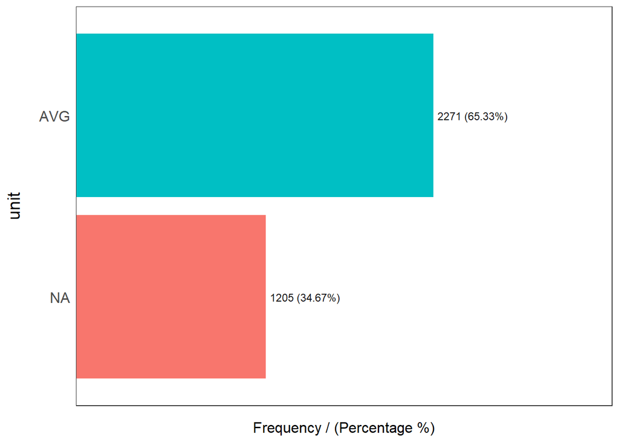

```
##   unit frequency percentage cumulative_perc
## 1  AVG      2271      65.33           65.33
## 2   NA      1205      34.67          100.00
```

```
##                 agentia frequency percentage cumulative_perc
## 1              CHEMICAL      2787      80.18           80.18
## 2         NOT SPECIFIED       614      17.66           97.84
## 3  FERTILIZER: NITROGEN        20       0.58           98.42
## 4 FERTILIZER: PHOSPHATE        20       0.58           99.00
## 5    FERTILIZER: POTASH        20       0.58           99.58
## 6    FERTILIZER: SULFUR        15       0.43          100.00
```

```
##                                                                    compound
## 1                                                                        NA
## 2                                                 FUNGICIDE: CAPTAN = 81301
## 3                                            FUNGICIDE: CYPRODINIL = 288202
## 4                                             FUNGICIDE: FENHEXAMID = 90209
## 5                                            FUNGICIDE: FLUDIOXONIL = 71503
## 6                                          INSECTICIDE: BIFENTHRIN = 128825
## 7                                          FUNGICIDE: MYCLOBUTANIL = 128857
## 8                                           FUNGICIDE: PENTHIOPYRAD = 90112
## 9                                         FUNGICIDE: PYRACLOSTROBIN = 99100
## 10                                         FUNGICIDE: PYRIMETHANIL = 288201
## 11                                          HERBICIDE: FLUMIOXAZIN = 129034
## 12                                          INSECTICIDE: ABAMECTIN = 122804
## 13                                         INSECTICIDE: ACETAMIPRID = 99050
## 14                                 INSECTICIDE: BT KURSTAKI ABTS-351 = 6522
```

[output cut: 301 more lines]

[figure not shown]

```
##             Value frequency percentage cumulative_perc
## 1             (D)      1559      44.85           44.85
## 2            (NA)       189       5.44           50.29
## 3               0        68       1.96           52.25
## 4             1.2        27       0.78           53.03
## 5             1.5        24       0.69           53.72
## 6             1.3        23       0.66           54.38
## 7             1.4        22       0.63           55.01
## 8           1,100        19       0.55           55.56
## 9             1.1        18       0.52           56.08
## 10            1.6        16       0.46           56.54
## 11              2        16       0.46           57.00
## 12          1,000        14       0.40           57.40
## 13            1.7        14       0.40           57.80
## 14            1.8        14       0.40           58.20
```

[output cut: 845 more lines]

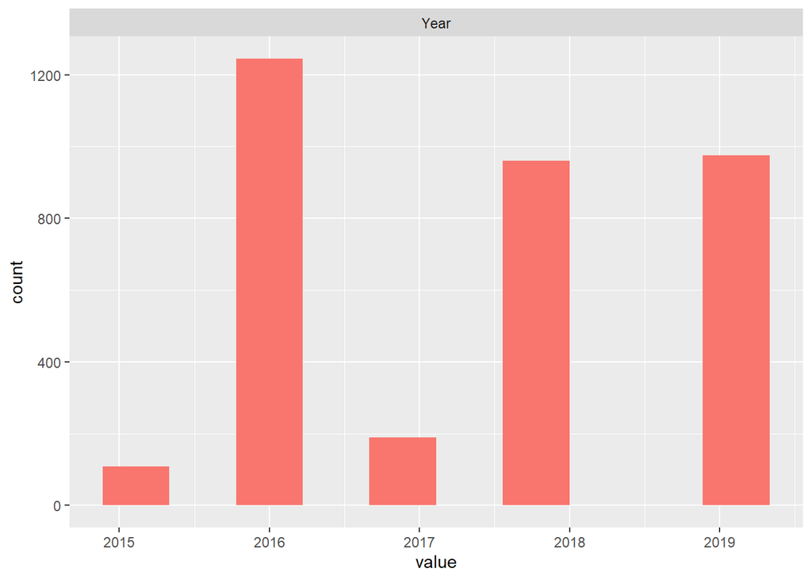

```r
index_ana <- c(2,6,17,18,19,20,23,24,25)

s_ana <- sberry[,index_ana]
basic_eda <- function(data){

  glimpse(data)

  df_status(data)

  freq(data)

  profiling_num(data)

  plot_num(data)

}

basic_eda(s_ana)
```

```r
##pcaberry <- prcomp(s_ana, center = T, scale. = T)
##summary(pcaberry, center = T, scale. = T)
##plot(pcaberry, type = "line")
##biplot(pcaberry, scale = 0)
```

Also, we can divide the dataset depending on different variables like “tame”, “wild”.

```r
index_tame <- grep("TAME", new2$type)
new_tame <- new2[index_tame,]
unique(new_tame$type)
```

```
## [1] " TAME - PRICE RECEIVED"  " TAME"
## [3] " TAME - ACRES HARVESTED" " TAME - PRODUCTION"
## [5] " TAME - YIELD"
```

```r
index_wild <- grep("WILD", new2$type)
new_wild <- new2[index_wild,]
```

## Reference

https://www.tidyverse.org/packages/ https://www.rdocumentation.org/packages/dplyr/versions/0.7.8 https://cran.r-project.org/web/packages/magrittr/vignettes/magrittr.html https://cran.r-project.org/web/packages/funModeling/index.html https://cran.r-project.org/web/packages/Hmisc/index.html